# P2_Project

## Studing the Titanic DataSet

### 0. Getting and preparing data

First, we import the data and prepare it to work with it, adding some necessary columns. We are going to work with a sample of 891 passengers, where only 342 of them survived (38%) and only a 35% of the passengers were females.

Among the variables, we want to analyze as dependent variable the survival or not survival of the passengers, and as independent variables the gender, the age, and the passenger class.

```python
# importing the necessary libraries
import pandas as pd
%matplotlib inline
import matplotlib.pyplot as plt
import seaborn as sns
```

```python
# reading data
df = pd.read_csv("titanic-data.csv")
print len(df)
df.groupby('Survived').count()
```

```
891
```

| Survived | PassengerId | Pclass | Name | Sex | Age | SibSp | Parch | Ticket | Fare | Cabin | Embarked |
| --- | --- | --- | --- | --- | --- | --- | --- | --- | --- | --- | --- |
| 0 | 549 | 549 | 549 | 549 | 424 | 549 | 549 | 549 | 549 | 68 | 549 |
| 1 | 342 | 342 | 342 | 342 | 290 | 342 | 342 | 342 | 342 | 136 | 340 |

```python
print "Survival percentage:",342*100.0/891
```

```
Survival percentage: 38.3838383838
```

```python
df.groupby('Sex')['PassengerId'].count()
```

```
Sex
female    314
male      577
Name: PassengerId, dtype: int64
```

```python
print "Women percentage:",314*100.0/891
```

```
Women percentage: 35.241301908
```

```python
# preparing more columns to work with the dataset
df['male'] = df["Sex"] == "male"
df['female'] = df["Sex"] == "female"
df['first'] = df["Pclass"] == 1
df['second'] = df["Pclass"] == 2
df['third'] = df["Pclass"] == 3
df['survivor'] = df["Survived"] == 1
df['deceased'] = df["Survived"] == 0
df['Cherbourg'] = df["Embarked"] == "C"
df['Queenstown'] = df["Embarked"] == "Q"
df['Southampton'] = df["Embarked"] == "S"

df.head(1)
```

|  | PassengerId | Survived | Pclass | Name | Sex | Age | SibSp | Parch | Ticket | Fare | ... | male | female | first | second | third | survivor | deceased | Cherbourg | Queenstown | Southampton |
| --- | --- | --- | --- | --- | --- | --- | --- | --- | --- | --- | --- | --- | --- | --- | --- | --- | --- | --- | --- | --- | --- |
| 0 | 1 | 0 | 3 | Braund, Mr. Owen Harris | male | 22.0 | 1 | 0 | A/5 21171 | 7.25 | ... | True | False | False | False | True | False | True | False | False | True |

1 rows × 22 columns

### 1. How much did the passenger class affect to the survival possibilities of a passenger?

First, we make a graph to get a general idea of the proportion of survivors per passenger class. Within the sample we have, we can see that clearly the 3rd class has the lowest survival possibilities of the three classes. Which could be explained by the fact that 3rd class passengers probably travelled in more crowded conditions at lower levels of the ship where escaping could have been more difficult than in others areas of the ship.

Then we make the numerical calculations to get the percentages, and as we can see, the highest survival percentage in this sample is shown in first class with the 63%, while the lowest is for third class with only the 24%, an increment of 40 percentage units between first and third class.

| Pclass | survivor | deceased | % survival |
| --- | --- | --- | --- |
| 1 | 136.0 | 80.0 | 62.96 |
| 2 | 87.0 | 97.0 | 47.28 |
| 3 | 119.0 | 372.0 | 24.24 |

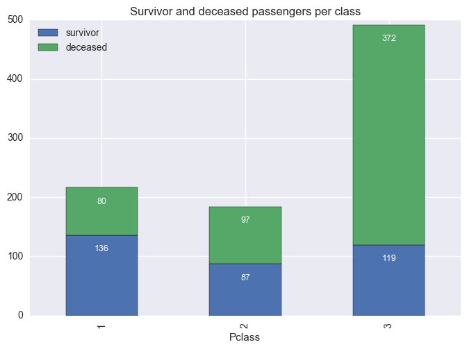

```python
axes = df.groupby("Pclass").sum().plot.bar(y=["survivor","deceased"],stacked=True, title="Survivor and deceased passengers per class")
for p in axes.patches[0:3]:
    axes.text(p.get_x() + p.get_width()/2, # x positions
            p.get_height()-30,             # y position
            int(p.get_height()),           # label text
            ha='center', va='bottom', color='white', fontsize=9) # fontdict with font alignment and properties

for p in axes.patches[3:]:
    lower_i = axes.patches.index(p)
    lower_h = axes.patches[lower_i-3].get_height()
    axes.text(p.get_x() + p.get_width()/2, # x positions
            p.get_height()+lower_h-30,             # y position
            int(p.get_height()),           # label text
            ha='center', va='bottom', color='white', fontsize=9) # fontdict with font alignment and properties
```

```python
sum_class = df.groupby("Pclass").sum().loc[:, ["survivor", "deceased"]]
sum_class["% survival"] = (sum_class['survivor']/(sum_class['survivor']+sum_class['deceased'])) * 100
sum_class
```

| Pclass | survivor | deceased | % survival |
| --- | --- | --- | --- |
| 1 | 136.0 | 80.0 | 62.962963 |
| 2 | 87.0 | 97.0 | 47.282609 |
| 3 | 119.0 | 372.0 | 24.236253 |

### 2. How did the age affect to the survival possibilities?

First, we make a graph to get a general idea of the proportion of survivors per age. Within the sample we have, there is a big amount of deceased people between 20 and 30 years old, but this group is also the largest one in our sample, so we need to have a look at the numbers.

[output not shown]

```python
ages = df[['Survived','Age']].copy()
ages['survivor'] = df.loc[df['Survived'] == 1,'Age']
ages['deceased'] = df.loc[df['Survived'] == 0,'Age']
ages.head(2)
```

|  | Survived | Age | survivor | deceased |
| --- | --- | --- | --- | --- |
| 0 | 0 | 22.0 | NaN | 22.0 |
| 1 | 1 | 38.0 | 38.0 | NaN |

```
60
```

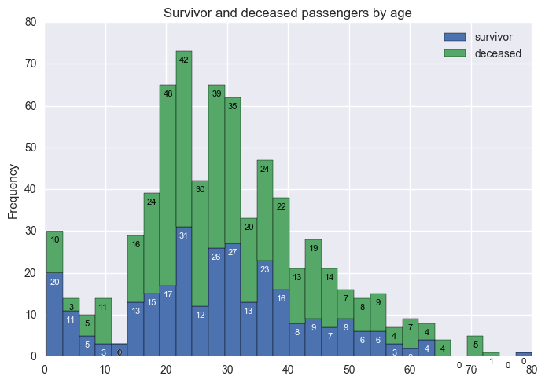

```python
axes = ages[['survivor','deceased']].plot.hist(stacked=True, bins=30, title="Survivor and deceased passengers by age")
print len(axes.patches)
for p in axes.patches[0:30]:
    axes.text(p.get_x() + p.get_width()/2, # x positions
            p.get_height()-3,             # y position
            int(p.get_height()),           # label text
            ha='center', va='bottom', color='white', fontsize=8) # fontdict with font alignment and properties
for p in axes.patches[30:]:
    lower_i = axes.patches.index(p)
    lower_h = axes.patches[lower_i-30].get_height()
    axes.text(p.get_x() + p.get_width()/2, # x positions
            p.get_height()+lower_h-3,             # y position
            int(p.get_height()),           # label text
            ha='center', va='bottom', color='black', fontsize=8) # fontdict with font alignment and properties
```

```python
pass_20_30 = df[(df['Age'] > 20) & (df['Age'] < 31)]
print "survivors 20 - 30: ",(pass_20_30['Survived'].sum())*100.0/len(pass_20_30)
pass_20 = df[(df['Age'] > 20)]
print "survivors under 20: ",(pass_20['Survived'].sum())*100.0/len(pass_20)
pass_30 = df[(df['Age'] >= 31)]
print "survivors over 30: ",(pass_30['Survived'].sum())*100.0/len(pass_30)
```

[output not shown]

### 3. How did the gender affect to the survival possibilities?

First, we make a graph to get a general idea of the proportion of survivors per sex. Within the sample we have we can see clearly that women survived proportionally much more than men.

If we look at the numbers we can see that a 74% of females survived while only a 19% of males survived, more than 50 percentage units of difference.

| Sex | survivor | deceased | % survival |
| --- | --- | --- | --- |
| female | 233.0 | 81.0 | 74.20 |
| male | 109.0 | 468.0 | 18.89 |

This situation could be related with the fact that we know now that the Titanic didn't carry lifeboats for all the passengers and it is possible that they were filled mostly with women and children according to the unofficial code of ["women and children first"](https://en.wikipedia.org/wiki/Women_and_children_first) for maritime disasters. This theory is supported by [Elinder & Erixson's](http://www.pnas.org/content/109/33/13220.abstract) 2012 study in which they also explain that only a 20% of all the males survived. This percentage matches with the one of our sample.

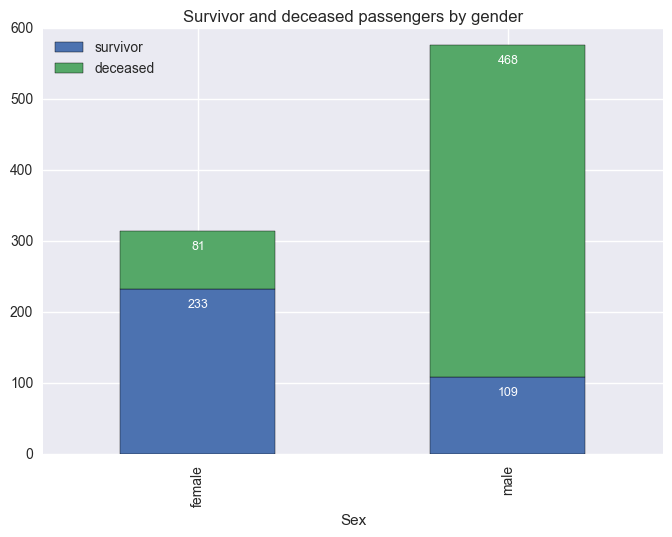

```python
axes = df.groupby("Sex").sum().plot.bar(y=["survivor","deceased"],stacked=True, title="Survivor and deceased passengers by gender")
for p in axes.patches[0:2]:
    axes.text(p.get_x() + p.get_width()/2, # x positions
            p.get_height()-30,             # y position
            int(p.get_height()),           # label text
            ha='center', va='bottom', color='white', fontsize=9) # fontdict with font alignment and properties

for p in axes.patches[2:]:
    lower_i = axes.patches.index(p)
    lower_h = axes.patches[lower_i-2].get_height()
    axes.text(p.get_x() + p.get_width()/2, # x positions
            p.get_height()+lower_h-30,             # y position
            int(p.get_height()),           # label text
            ha='center', va='bottom', color='white', fontsize=9) # fontdict with font alignment and properties
```

```python
sum_sex = df.groupby("Sex").sum().loc[:, ["survivor", "deceased"]]
sum_sex["% survival"] = (sum_sex['survivor']/(sum_sex['survivor']+sum_sex['deceased'])) * 100
sum_sex
```

| Sex | survivor | deceased | % survival |
| --- | --- | --- | --- |
| female | 233.0 | 81.0 | 74.203822 |
| male | 109.0 | 468.0 | 18.890815 |

### 4. Where females proportionally younger or older than males? How age and gender affected together to the survival possibilities?

First we study the tendency and variability of the ages of males and females.

|  | mean | median | std |
| --- | --- | --- | --- |
| WOMEN | 27.91 | 27.0 | 14.11 |
| MEN | 30.73 | 29.0 | 14.68 |

In both cases the distribution of ages look very similar with means between 27 and 31 and very similar standard deviations. We also represent the distribution of ages graphically with a boxplot and a histogram. Attending to these results we cannot say that female and male survival differences was affected by its age, being both age distributions very similar for males and females.

We also represent the distribution of survivors by gender and age and we can see that in almost all the cases surviving possibilities for men were much lower than for women.

Finally we calculate the percentage of survival in the "critical age" between 20 and 30 years, and we can see that in that range male survival is even less than for the whole sample (a difference of almos 60 percentage units between male and females):

|  | % |
| --- | --- |
| female survivors 20 - 30 | 74.39 |
| male survivors 20 - 30 | 15.33 |

We can say that being male and between 20 and 30 years old was the worst combination of age and gender regarding survival possibilities in the Titanic.

```python
ages_sex = df[['Sex','Age']].copy()
ages_sex['male'] = df.loc[df['Sex'] == 'male','Age']
ages_sex['female'] = df.loc[df['Sex'] == 'female','Age']
ages_sex.head(2)
```

|  | Sex | Age | male | female |
| --- | --- | --- | --- | --- |
| 0 | male | 22.0 | 22.0 | NaN |
| 1 | female | 38.0 | NaN | 38.0 |

```python
print "WOMEN"
print "mean:",ages_sex['female'].mean()
print "median:",ages_sex['female'].median()
print "std:",ages_sex['female'].std()
print "MEN"
print "mean:",ages_sex['male'].mean()
print "median:",ages_sex['male'].median()
print "std:",ages_sex['male'].std()
```

```
WOMEN
mean: 27.9157088123
median: 27.0
std: 14.1101464575
MEN
mean: 30.7266445916
median: 29.0
std: 14.6782008238
```

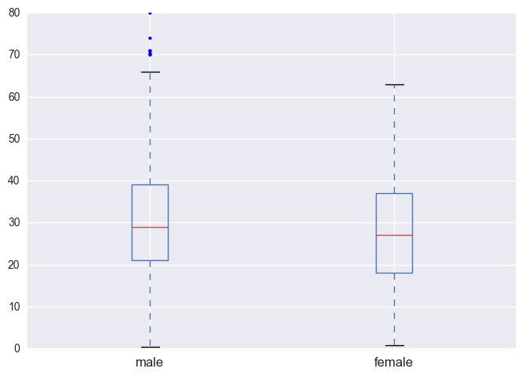

```python
ages_sex[['male',"female"]].boxplot(sym=".")
```

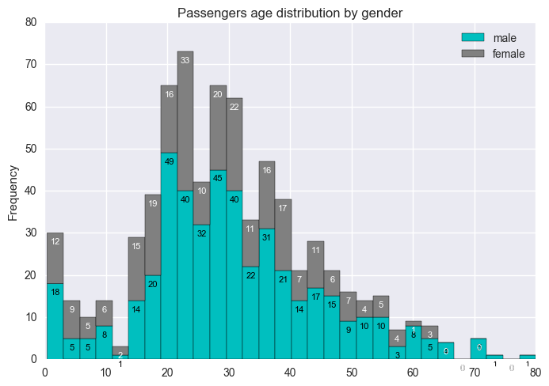

```python
axes = ages_sex[['male','female']].plot.hist(stacked=True, bins=30, color=["c","grey"], title='Passengers age distribution by gender')
for p in axes.patches[0:30]:
    axes.text(p.get_x() + p.get_width()/2, # x positions
            p.get_height()-3,             # y position
            int(p.get_height()),           # label text
            ha='center', va='bottom', color='black', fontsize=8) # fontdict with font alignment and properties
for p in axes.patches[30:]:
    lower_i = axes.patches.index(p)
    lower_h = axes.patches[lower_i-30].get_height()
    axes.text(p.get_x() + p.get_width()/2, # x positions
            p.get_height()+lower_h-3,             # y position
            int(p.get_height()),           # label text
            ha='center', va='bottom', color='white', fontsize=8) # fontdict with font alignment and properties
```

```python
ages_sex_s = df.loc[df['Survived'] == 1,['Sex','Age']].copy()
ages_sex_s['male'] = df.loc[df['Sex'] == 'male','Age']
ages_sex_s['female'] = df.loc[df['Sex'] == 'female','Age']
ages_sex_s.head(2)
```

|  | Sex | Age | male | female |
| --- | --- | --- | --- | --- |
| 1 | female | 38.0 | NaN | 38.0 |
| 2 | female | 26.0 | NaN | 26.0 |

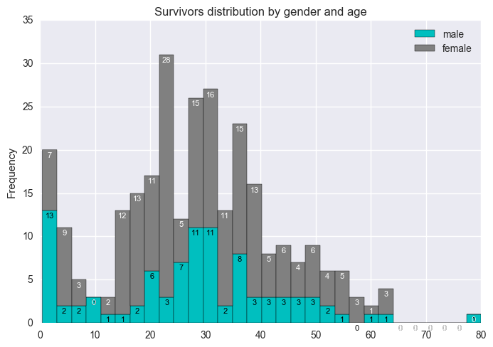

```python
axes = ages_sex_s[['male','female']].plot.hist(stacked=True, bins=30, color=["c","grey"], title="Survivors distribution by gender and age")
for p in axes.patches[0:30]:
    axes.text(p.get_x() + p.get_width()/2, # x positions
            p.get_height()-1,             # y position
            int(p.get_height()),           # label text
            ha='center', va='bottom', color='black', fontsize=8) # fontdict with font alignment and properties
for p in axes.patches[30:]:
    lower_i = axes.patches.index(p)
    lower_h = axes.patches[lower_i-30].get_height()
    axes.text(p.get_x() + p.get_width()/2, # x positions
            p.get_height()+lower_h-1,             # y position
            int(p.get_height()),           # label text
            ha='center', va='bottom', color='white', fontsize=8) # fontdict with font alignment and properties
```

```python
pass_20_30_f = df[(df['Age'] > 20) & (df['Age'] < 31) & (df['Sex']=='female')]
print "female survivors 20 - 30: ",(pass_20_30_f['Survived'].sum())*100.0/len(pass_20_30_f)
pass_20_30_m = df[(df['Age'] > 20) & (df['Age'] < 31)& (df['Sex']=='male')]
print "male survivors 20 - 30: ",(pass_20_30_m['Survived'].sum())*100.0/len(pass_20_30_m)
```

```
female survivors 20 - 30:  74.3902439024
male survivors 20 - 30:  15.3333333333
```

### 5. Where there more females or males in each passenger class? Could both variables, gender and class, affect differently together than separately to the survival possibilities?

We first plot the gender distribution of passengers per class in this sample and we can see that definitely the distribution is not even, a great proportion of males were travelling in third class.

We calculate the proportion of survival for both males and females in every class:

| Pclass | male | female | % male | % female | % m surv | % f surv |
| --- | --- | --- | --- | --- | --- | --- |
| 1 | 122.0 | 94.0 | 56.48 | 43.52 | 36.89 | 96.81 |
| 2 | 108.0 | 76.0 | 58.70 | 41.30 | 15.74 | 92.11 |
| 3 | 347.0 | 144.0 | 70.67 | 29.33 | 13.54 | 50.00 |

If we compare it with the global survival possibilities by gender:

| Sex | survivor | deceased | % survival |
| --- | --- | --- | --- |
| female | 233.0 | 81.0 | 74.20 |
| male | 109.0 | 468.0 | 18.89 |

And the percentages of survival by class:

| Pclass | survivor | deceased | % survival |
| --- | --- | --- | --- |
| 1 | 136.0 | 80.0 | 62.96 |
| 2 | 87.0 | 97.0 | 47.28 |
| 3 | 119.0 | 372.0 | 24.24 |

We can see that given the sample we have, the proportion of survivor females increments in 20 percentage units if the female was traveling in first or second class, but decreases 20 percentage units if she was travelling in third class. Regarding males, travelling in first class increments the proportion of survivors in 20 percentage units, but travelling in second or third class, doesn't affect much to the proportion of survivors. For every class, the proportion of females survivors is much higher than male survivors, being the biggest difference in percentage points between females and males in the second class.

Attending to the percentages, the gender is the variable that affects alone the most to the survival probabilities (around 50 percentage units of difference), but that difference increments when considering both gender and class (more than 80 percentage points between males in third class and females in first class).

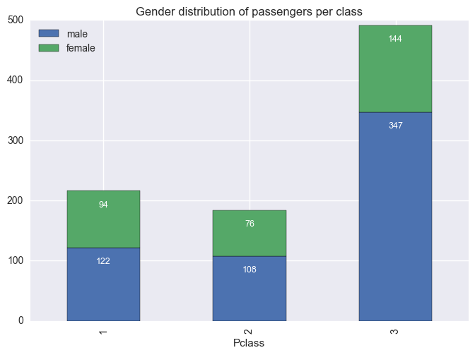

```python
axes = df.groupby(["Pclass"]).sum().plot.bar(y=["male","female"],stacked=True, title="Gender distribution of passengers per class")
for p in axes.patches[0:3]:
    axes.text(p.get_x() + p.get_width()/2, # x positions
            p.get_height()-30,             # y position
            int(p.get_height()),           # label text
            ha='center', va='bottom', color='white', fontsize=9) # fontdict with font alignment and properties

for p in axes.patches[3:]:
    lower_i = axes.patches.index(p)
    lower_h = axes.patches[lower_i-3].get_height()
    axes.text(p.get_x() + p.get_width()/2, # x positions
            p.get_height()+lower_h-30,             # y position
            int(p.get_height()),           # label text
            ha='center', va='bottom', color='white', fontsize=9) # fontdict with font alignment and properties
```

```python
sum_class = df.groupby("Pclass").sum().loc[:, ["male", "female"]]
sum_class["% male"] = (sum_class['male']/(sum_class['male']+sum_class['female'])) * 100
sum_class["% female"] = (sum_class['female']/(sum_class['male']+sum_class['female'])) * 100
sum_class
```

| Pclass | male | female | % male | % female |
| --- | --- | --- | --- | --- |
| 1 | 122.0 | 94.0 | 56.481481 | 43.518519 |
| 2 | 108.0 | 76.0 | 58.695652 | 41.304348 |
| 3 | 347.0 | 144.0 | 70.672098 | 29.327902 |

```python
surv_gender_class = df.groupby(["Pclass","Sex","Survived"])['PassengerId'].count()
print surv_gender_class
```

```
Pclass  Sex     Survived
1       female  0             3
                1            91
        male    0            77
                1            45
2       female  0             6
                1            70
        male    0            91
                1            17
3       female  0            72
                1            72
        male    0           300
                1            47
Name: PassengerId, dtype: int64
```

```python
fem_0 = (surv_gender_class.loc[
        (slice(None),'female',0)]).values
fem_1 = (surv_gender_class.loc[
        (slice(None),'female',1)]).values
mal_0 = (surv_gender_class.loc[
        (slice(None),'male',0)]).values
mal_1 = (surv_gender_class.loc[
        (slice(None),'male',1)]).values

sum_class['% m surv'] = mal_1 * 100.0 / (mal_0 + mal_1)
sum_class['% f surv'] = fem_1 * 100.0 / (fem_0 + fem_1)
sum_class
```

| Pclass | male | female | % male | % female | % m surv | % f surv |
| --- | --- | --- | --- | --- | --- | --- |
| 1 | 122.0 | 94.0 | 56.481481 | 43.518519 | 36.885246 | 96.808511 |
| 2 | 108.0 | 76.0 | 58.695652 | 41.304348 | 15.740741 | 92.105263 |
| 3 | 347.0 | 144.0 | 70.672098 | 29.327902 | 13.544669 | 50.000000 |

### 6. Is there any relation between the port of embarkment and the survival possibilities?

Firts, we make a graph to get a general idea of the proportion of survivors per embarkment port as well as the proportion of each passenger class that embarked on each port. Southampton is by far the port where most people of the current sample embarked. We can see a high proportion of deceases among those passengers but also that the majority of the Southampton passengers travelled in third class.

Only a 34% of this sample passengers that embarked in the port of Southampton survived, this is probably related to the class they were travelling in, we cannot assumen there is any relation between the port of embarkement and the probability to survive, without further study.

| Embarked | survivor | deceased | % survival |
| --- | --- | --- | --- |
| Cherbourg | 93.0 | 75.0 | 55.36 |
| Quenstown | 30.0 | 47.0 | 38.96 |
| Southampton | 217.0 | 427.0 | 33.70 |

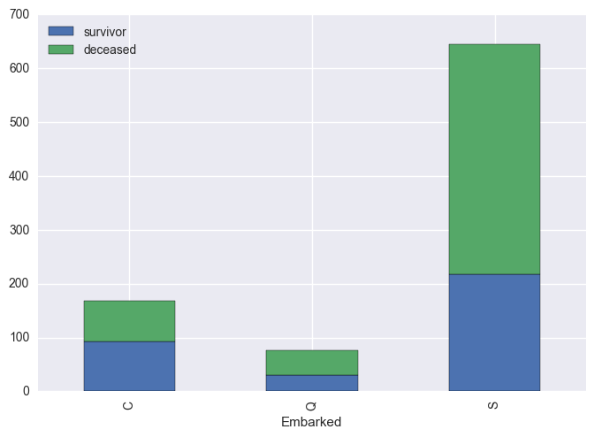

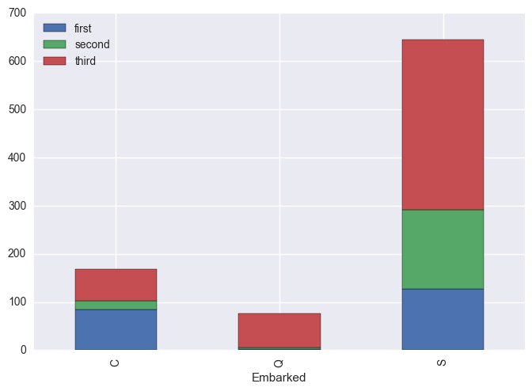

```python
df.groupby("Embarked").sum().plot.bar(y=["survivor","deceased"],stacked=True)
df.groupby("Embarked").sum().plot.bar(y=["first","second","third"],stacked=True)
```

```python
sum_emb = df.groupby("Embarked").sum().loc[:, ["survivor", "deceased"]]
sum_emb["% survival"] = (sum_emb['survivor']/(sum_emb['survivor']+sum_emb['deceased'])) * 100
sum_emb
```

| Embarked | survivor | deceased | % survival |
| --- | --- | --- | --- |
| C | 93.0 | 75.0 | 55.357143 |
| Q | 30.0 | 47.0 | 38.961039 |
| S | 217.0 | 427.0 | 33.695652 |